# hw2_2

**3. Using the model fit in Step 1 above, make a plot of the expected difference between women and men in expenditures as a function of age. Add a horizontal line at 0. Note that this difference is a simple function of the estimated coefficients from the model. (Hint: Start by writing out the regression model for females and males, both will be a function of age and the regression coefficients. Then take the difference and plug in the estimated regression coefficients and allow age to range from 65 to 94.)**

```r
## The function calculates the difference as male-female
## Later I use -diff_val(age) to obtain the value of female-male
betas = coef(model1)
diff_val <- function(age){
    sapply(age, function(age){
        ydiff=numeric()
    if (age<75){
        ydiff = -betas['female'] -betas['agem65:female']*(age-65)
    }else if (age<85){
        age75 = ifelse(age-75>0, age-75,0)
        ydiff = -betas['female']-betas['agem65:female']*(age-65) -betas['age_sp1:female']*(age75)
    }else if(age>=85){
        age75 = ifelse(age-75>0, age-75,0)
        age85 = ifelse(age-85>0, age-85,0)
        ydiff = -betas['female']-betas['agem65:female']*(age-65) -betas['age_sp1:female']*(age75) - betas['age_sp2:female']*(age85)
    }
    return(as.numeric(ydiff))
})
}
```

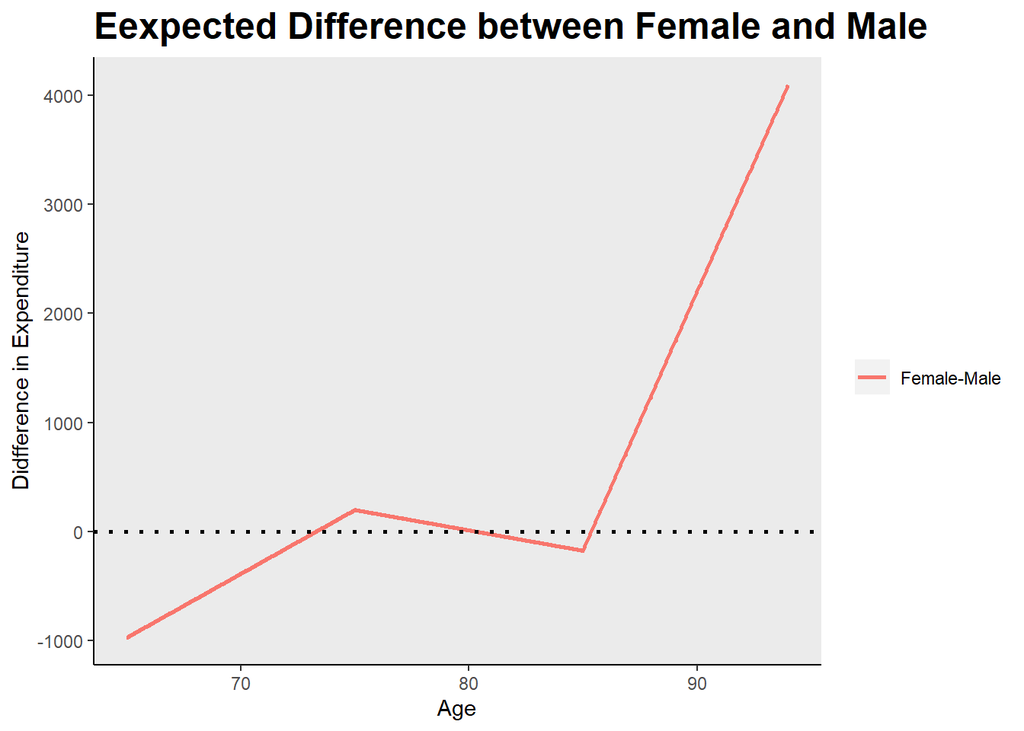

```r
library(ggplot2)
xdiff = seq(65,94, length.out = 1000)
dat <- data.frame(xdfif = xdiff)
dat$ydiff= diff_val(xdiff)
ggplot(data = dat) +
geom_line(aes(x = xdiff, y = -ydiff, color = "Female-Male"), size = 1)+
geom_hline(yintercept=0, color = "black", size=1, linetype="dotted")+
ggtitle('Eexpected Difference between Female and Male')+
ylab('Didfference in Expenditure')+
xlab('Age')+
labs(color = "")+
  theme(panel.border = element_blank(),
        panel.grid.major = element_blank(),
        panel.grid.minor = element_blank(),
        axis.line = element_line(colour = "black"),
        plot.title = element_text(size = 18, face = "bold"))
```

**4444 don’t forget!**  
**4. Use the appropriate linear combination of regression coefficients to calculate the estimated difference between females and males in average expenditures and its standard error at ages 65, 75 and 85 years. Complete the table below.**

```r
## age at 65
LMSE65 = 614.70
coef(model1)['female'];confint(model1)['female',]
```

```
##    female
## -974.5175
```

```
##      2.5 %     97.5 %
## -2179.5662   230.5313
```

```r
library(multcomp)
## age at 75
df = summary(model1)$df[2] ## df = 5686
summary(glht(model1, linfct = "`female`+ 10*`agem65:female`=0"))
```

```
##
##   Simultaneous Tests for General Linear Hypotheses
##
## Fit: lm(formula = totalexp ~ ((agem65 + age_sp1 + age_sp2) + female +
##     female * (agem65 + age_sp1 + age_sp2)), data = d)
##
## Linear Hypotheses:
##                                    Estimate Std. Error t value Pr(>|t|)
## female + 10 * `agem65:female` == 0    197.7      572.0   0.346     0.73
## (Adjusted p values reported -- single-step method)
```

```r
LMSE75 = 572.0
CI75 =  197.7 + c(-1,1)*(qt(0.975,df))*572.0
CI75
```

```
## [1] -923.6381 1319.0381
```

```r
## age at 85
df = summary(model1)$df[2] ## df = 5686
summary(glht(model1, linfct = "`female`+ 20*`agem65:female` + 10*`age_sp1:female`=0"))
```

```
##
##   Simultaneous Tests for General Linear Hypotheses
##
## Fit: lm(formula = totalexp ~ ((agem65 + age_sp1 + age_sp2) + female +
##     female * (agem65 + age_sp1 + age_sp2)), data = d)
##
## Linear Hypotheses:
##                                                            Estimate Std. Error
## female + 20 * `agem65:female` + 10 * `age_sp1:female` == 0   -176.1      948.0
##                                                            t value Pr(>|t|)
## female + 20 * `agem65:female` + 10 * `age_sp1:female` == 0  -0.186    0.853
## (Adjusted p values reported -- single-step method)
```

```r
LMSE85 = 948.0
CI85 = -176.1 + c(-1,1)*(qt(0.975,df))*948.0
CI85
```

```
## [1] -2034.541  1682.341
```

*Bootstrap Standard Error and 95% Confidence Interaval*

```r
library(boot) ## Bootstrap using data set "d", model1
exp.est <- function(data, id){
    dt <- data[id,] # allows boot to select sample
    fit1 <- lm(formula = totalexp ~ ((agem65 + age_sp1 + age_sp2) + female + female * (agem65 + age_sp1 + age_sp2)), data = dt)
    diff65 <- coef(fit1)[5]
    diff75 <- coef(fit1)[5] + 10*coef(fit1)[6]
    diff85 <- coef(fit1)[5] + 20*coef(fit1)[6] + 10*coef(fit1)[7]
    ratio <- 1 + coef(fit1)[5]/coef(fit1)[1]
    c(diff65,diff75,diff85,ratio)
}

set.seed(520)
exp.result <- boot(d, exp.est, R=7000)
exp.result
```

```
##
## ORDINARY NONPARAMETRIC BOOTSTRAP
##
##
## Call:
## boot(data = d, statistic = exp.est, R = 7000)
##
##
## Bootstrap Statistics :
##         original      bias     std. error
## t1* -974.5174711  4.62577583  591.8773784
## t2*  197.7029449 -7.90446233  572.5587492
## t3* -176.1208926 11.61150317 1087.9932360
## t4*    0.7657065  0.01089868    0.1254445
```

```r
# The element $t contains a total number of R values (i.e. number of bootstrap samples) for each statistic generated by the bootstrap procedure:
head(exp.result$t)
```

```
##              [,1]       [,2]      [,3]      [,4]
## [1,]  -720.080947   45.30669 -105.9495 0.8256961
## [2,]  -300.887124   40.73766 -824.2698 0.9105070
## [3,]    38.661269  -34.56610  611.9328 1.0112885
## [4,]  -118.011977  908.87170  909.2618 0.9665051
## [5,]     2.746883 -448.64727 -519.5391 1.0007290
## [6,] -1261.091392  594.66140  112.5384 0.6762447
```

```r
# Using bca is too slow and can not be finished within 1hr, so I choose type = "norm"
exp.bootci <- sapply(1:4,function(x) boot.ci(exp.result,index = x,type = "norm")$normal[2:3])
exp.boot.result <- data.frame(rbind(exp.result$t0,exp.bootci))
rownames(exp.boot.result) <- c("Est","Lower","Upper")
colnames(exp.boot.result) <- c("diff65","diff75","diff85","ratio")
round(exp.boot.result, 3)
```

```
##          diff65   diff75    diff85 ratio
## Est    -974.517  197.703  -176.121 0.766
## Lower -2139.202 -916.587 -2320.160 0.509
## Upper   180.915 1327.802  1944.695 1.001
```

| Age | Est. Diff | LM Std.Error | LM 95% CI | BS Diff | BS Std.Err | BS 95% CI |
| --- | --- | --- | --- | --- | --- | --- |
| 65 | -974.5174711 | $614.7$ | $[-2179.57, 230.53]$ | $-974.517$ | $591.88$ | $[-2139.20,180.92]$ |
| 75 | 197.7029449 | $572.0$ | $[-923.64, 1319.04]$ | $197.703$ | $572.56$ | $[-916.59,1327.80]$ |
| 85 | -176.1208926 | $948.0$ | $[-2034.54, 1682.34]$ | $-176.121$ | $1088.00$ | $[-2320.16,1944.70]$ |

[output not shown]

$$\nabla
=\begin{bmatrix}
-\frac{\beta_4}{\beta_0^2} \\
0 \\
0 \\
0 \\
\frac{1}{\beta_0} \\
... \\
0
\end{bmatrix}$$
## https://www.physicsread.com/latex-gradient-operator/

```r
gmatrix <- matrix(c(-betas['female']/betas[1]^2,0,0,0,1/betas[1],0,0,0),ncol = 1)
gmatrix
```

```
##              [,1]
## [1,] 5.632887e-05
## [2,] 0.000000e+00
## [3,] 0.000000e+00
## [4,] 0.000000e+00
## [5,] 2.404201e-04
## [6,] 0.000000e+00
## [7,] 0.000000e+00
## [8,] 0.000000e+00
```

**6. The data used in this regression are highly skewed and heteroscedastic (unequal variances across observations). Hence, the assumptions of the linear regression are not consistent with patterns in the data. As you will learn shortly, the estimates are still unbiased, but the standard errors and confidence intervals are likely biased. Hence, your inferences (tests and CIs) that depend on both the mean and variance estimates may be incorrect.**

**To check, use the bootstrap procedure to estimate the standard errors and confidence intervals for the differences in the table in Question 4 and for the ratio in Question 5. Compare the results obtained directly from the linear regression with those obtained using bootstrapping.**

**7. Test the null hypothesis that on average, males and females use the same quantity of medical services; i.e. are the mean expenditures at any age the same for males and females? Use a likelihood ratio test performed by fitting a null and extended model and comparing the change in –2*log likelihood to the appropriate chi-square statistic. In addition, perform an F-test for the same null hypothesis. Write a sentence or two that summarizes what you learned about the medical expenditures and age from this test and the similarity/difference of the two tests.**

Null model: $E[Y] = \beta_0 + \beta_1(age-65) + \beta_2(age-75)^+ + \beta_3(age-85)^+ + \epsilon$  
Extended model: $E[Y] = \beta_0 + \beta_1(age-65) + \beta_2(age-75)^+ + \beta_3(age-85)^+ + \beta_4*female + \beta_5 (age-65)*female + \beta_6(age-75)^+*female + \beta_7(age-85)^+*female + \epsilon$

```r
# I have alreaday fitted the extended model previously and named it model1
model0 = lm(totalexp~ ((agem65 + age_sp1 + age_sp2)), data = d)
summary(model0)
```

```
##
## Call:
## lm(formula = totalexp ~ ((agem65 + age_sp1 + age_sp2)), data = d)
##
## Residuals:
##    Min     1Q Median     3Q    Max
##  -7485  -3909  -3215  -1026 171268
##
## Coefficients:
##             Estimate Std. Error t value Pr(>|t|)
## (Intercept)  3582.73     301.98  11.864   <2e-16 ***
## agem65         81.69      48.17   1.696   0.0899 .
## age_sp1        40.25      95.99   0.419   0.6750
## age_sp2        85.35     193.85   0.440   0.6597
## ---
## Signif. codes:  0 '***' 0.001 '**' 0.01 '*' 0.05 '.' 0.1 ' ' 1
##
## Residual standard error: 10560 on 5690 degrees of freedom
## Multiple R-squared:  0.004917,   Adjusted R-squared:  0.004392
## F-statistic: 9.371 on 3 and 5690 DF,  p-value: 3.551e-06
```

```r
library(lmtest)
#Likelihood ratio test
lrtest(model0, model1)
```

```
## Likelihood ratio test
##
## Model 1: totalexp ~ ((agem65 + age_sp1 + age_sp2))
## Model 2: totalexp ~ ((agem65 + age_sp1 + age_sp2) + female + female *
##     (agem65 + age_sp1 + age_sp2))
##   #Df LogLik Df Chisq Pr(>Chisq)
## 1   5 -60831
## 2   9 -60828  4 5.158     0.2715
```

```r
#F test
anova(model0, model1)
```

```
## Analysis of Variance Table
##
## Model 1: totalexp ~ ((agem65 + age_sp1 + age_sp2))
## Model 2: totalexp ~ ((agem65 + age_sp1 + age_sp2) + female + female *
##     (agem65 + age_sp1 + age_sp2))
##   Res.Df        RSS Df Sum of Sq      F Pr(>F)
## 1   5690 6.3439e+11
## 2   5686 6.3381e+11  4 574407318 1.2883 0.2721
```

The results of Log likelihood test and F test are almost the same. P-value of Log likelihood test is 0.2715 and p-value of F test is 0.2721. According these p-values, we would fail to reject the null hypothesis that the interaction terms and $\beta_4(female)$ are not needed. We have no evidence that the extended model are more superior than the null model.

**8. Using the results of Questions 1-7, write a brief report with sections: Background and objective, data, methods, results, discussion as if for a health services journal. NOTE: The data section should briefly (in a sentence or two) describe the data source (e.g. 1987 NMES). Recall the question: Do older males and females of the same age use roughly the same quantity of medical services.**